# Power

## Power

- Power is the probability of rejecting the null hypothesis when it is false
- Ergo, power (as its name would suggest) is a good thing; you want more power
- A type II error (a bad thing, as its name would suggest) is failing to reject the null hypothesis when it's false; the probability of a type II error is usually called \(\beta\)
- Note Power \(= 1 - \beta\)

## Notes

- Consider our previous example involving RDI
- \(H_0: \mu = 30\) versus \(H_a: \mu > 30\)
- Then power is

\[ P\left(\frac{\bar X - 30}{s /\sqrt{n}} > t_{1-\alpha,n-1} ~|~ \mu = \mu_a \right) \]

- Note that this is a function that depends on the specific value of \(\mu_a\)!
- Notice as \(\mu_a\) approaches \(30\) the power approaches \(\alpha\)

## Calculating power for Gaussian data

Assume that \(n\) is large and that we know \(\sigma\)

\[ \begin{aligned} 1 -\beta & = P\left(\frac{\bar X - 30}{\sigma /\sqrt{n}} > z_{1-\alpha} ~|~ \mu = \mu_a \right)\\ & = P\left(\frac{\bar X - \mu_a + \mu_a - 30}{\sigma /\sqrt{n}} > z_{1-\alpha} ~|~ \mu = \mu_a \right)\\ \\ & = P\left(\frac{\bar X - \mu_a}{\sigma /\sqrt{n}} > z_{1-\alpha} - \frac{\mu_a - 30}{\sigma /\sqrt{n}} ~|~ \mu = \mu_a \right)\\ \\ & = P\left(Z > z_{1-\alpha} - \frac{\mu_a - 30}{\sigma /\sqrt{n}} ~|~ \mu = \mu_a \right)\\ \\ \end{aligned} \]

## Example continued

- Suppose that we wanted to detect a increase in mean RDI of at least 2 events / hour (above 30).
- Assume normality and that the sample in question will have a standard deviation of \(4\);
- What would be the power if we took a sample size of \(16\)?
- \(Z_{1-\alpha} = 1.645\)
- \(\frac{\mu_a - 30}{\sigma /\sqrt{n}} = 2 / (4 /\sqrt{16}) = 2\)
- \(P(Z > 1.645 - 2) = P(Z > -0.355) = 64\%\)

```r
pnorm(-0.355, lower.tail = FALSE)
```

```
## [1] 0.6387052
```

## Note

- Consider \(H_0 : \mu = \mu_0\) and \(H_a : \mu > \mu_0\) with \(\mu = \mu_a\) under \(H_a\).
- Under \(H_0\) the statistic \(Z = \frac{\sqrt{n}(\bar X - \mu_0)}{\sigma}\) is \(N(0, 1)\)
- Under \(H_a\) \(Z\) is \(N\left( \frac{\sqrt{n}(\mu_a - \mu_0)}{\sigma}, 1\right)\)
- We reject if \(Z > Z_{1-\alpha}\)

```
sigma <- 10; mu_0 = 0; mu_a = 2; n <- 100; alpha = .05
plot(c(-3, 6),c(0, dnorm(0)), type = "n", frame = FALSE, xlab = "Z value", ylab = "")
xvals <- seq(-3, 6, length = 1000)
lines(xvals, dnorm(xvals), type = "l", lwd = 3)
lines(xvals, dnorm(xvals, mean = sqrt(n) * (mu_a - mu_0) / sigma), lwd =3)
abline(v = qnorm(1 - alpha))
```

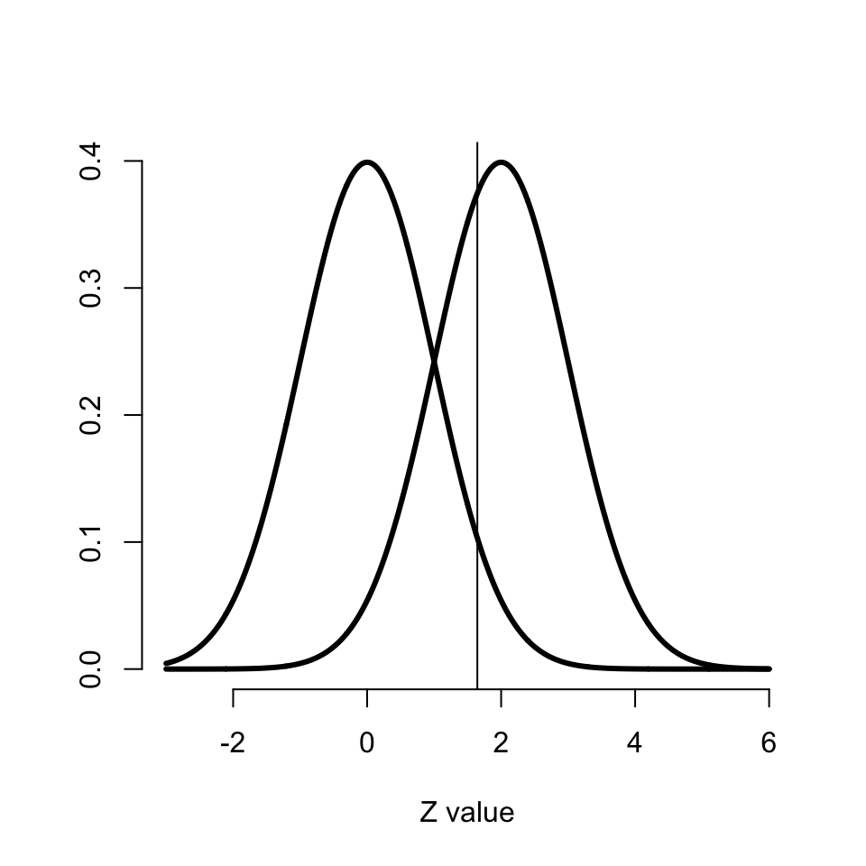

## Question

- When testing \(H_a : \mu > \mu_0\), notice if power is \(1 - \beta\), then \[1 - \beta = P\left(Z > z_{1-\alpha} - \frac{\mu_a - \mu_0}{\sigma /\sqrt{n}} ~|~ \mu = \mu_a \right) = P(Z > z_{\beta})\]
- This yields the equation \[z_{1-\alpha} - \frac{\sqrt{n}(\mu_a - \mu_0)}{\sigma} = z_{\beta}\]
- Unknowns: \(\mu_a\), \(\sigma\), \(n\), \(\beta\)
- Knowns: \(\mu_0\), \(\alpha\)
- Specify any 3 of the unknowns and you can solve for the remainder

## Notes

- The calculation for \(H_a:\mu < \mu_0\) is similar
- For \(H_a: \mu \neq \mu_0\) calculate the one sided power using \(\alpha / 2\) (this is only approximately right, it excludes the probability of getting a large TS in the opposite direction of the truth)
- Power goes up as \(\alpha\) gets larger
- Power of a one sided test is greater than the power of the associated two sided test
- Power goes up as \(\mu_1\) gets further away from \(\mu_0\)
- Power goes up as \(n\) goes up
- Power doesn't need \(\mu_a\), \(\sigma\) and \(n\), instead only \(\frac{\sqrt{n}(\mu_a - \mu_0)}{\sigma}\)
- The quantity \(\frac{\mu_a - \mu_0}{\sigma}\) is called the effect size, the difference in the means in standard deviation units.
- Being unit free, it has some hope of interpretability across settings

## T-test power

- Consider calculating power for a Gossett's \(T\) test for our example
- The power is \[ P\left(\frac{\bar X - \mu_0}{S /\sqrt{n}} > t_{1-\alpha, n-1} ~|~ \mu = \mu_a \right) \]
- Calcuting this requires the non-central t distribution.
- `power.t.test` does this very well
- Omit one of the arguments and it solves for it

## Example

```r
power.t.test(n = 16, delta = 2 / 4, sd=1, type = "one.sample",  alt = "one.sided")$power
```

```
## [1] 0.6040329
```

```r
power.t.test(n = 16, delta = 2, sd=4, type = "one.sample",  alt = "one.sided")$power
```

```
## [1] 0.6040329
```

```r
power.t.test(n = 16, delta = 100, sd=200, type = "one.sample", alt = "one.sided")$power
```

```
## [1] 0.6040329
```

## Example

```r
power.t.test(power = .8, delta = 2 / 4, sd=1, type = "one.sample",  alt = "one.sided")$n
```

```
## [1] 26.13751
```

```r
power.t.test(power = .8, delta = 2, sd=4, type = "one.sample",  alt = "one.sided")$n
```

```
## [1] 26.13751
```

```r
power.t.test(power = .8, delta = 100, sd=200, type = "one.sample", alt = "one.sided")$n
```

```
## [1] 26.13751
```